# Question

In a school, there are two clubs: club A and club B. Students can join one club, both clubs, or neither club.

- The number of students in at least one club is 44.
- The total number of students in the school is 69.
- The number of students in club A is 29.
- The number of students in both clubs (in A and B) is 16.

Calculate the following:

- How many students are only in club A (and not club B)? ##ANSWER1## students
- How many students are in neither club? ##ANSWER2## students
- How many students are only in club B (and not club A)? ##ANSWER3## students
- How many students are in club B? ##ANSWER4## students

## Answerlist

- 11
- 12
- 13
- 14
- 15
- 22
- 23
- 24
- 25
- 26
- 11
- 12
- 13
- 14
- 15
- 30
- 31
- 32
- 33
- 34

# Solution

- The number of students in only club A (and not club B) is 13.
- The number of students in neither club is 25.
- The number of students in only club B (and not club A) is 15.
- The number of students in club B is 31.

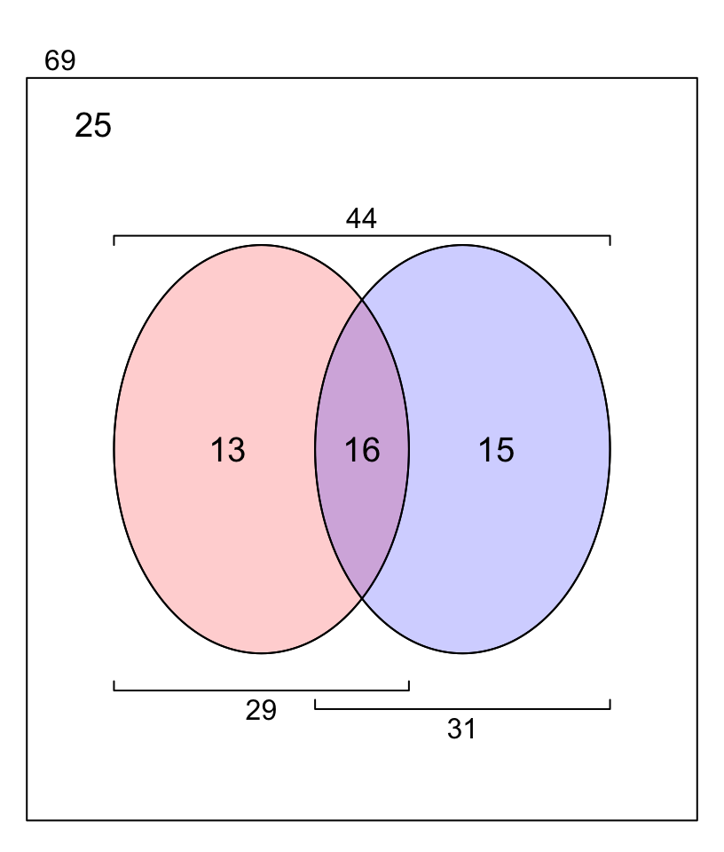

# Meta-information

extype: cloze exclozetype: schoice|schoice|schoice|schoice exsolution: 00100|00010|00001|01000 exname: venn_clubs